# irCLIP-RNP dataset of species mixing experiment to determine contribution of mouse/human unique peptides

Luca Ducoli

28 June, 2024

This is the pipeline used to analyze the irCLIP-RNP datasets of species-mixing experiement. We have subjected to MS two gel sections ranging from 30 to 70kDa (named “free RNA ligation zone”) and from 70 to 350KDa (named “whole RNP zone”). irCLIP-RNP for HNRNPC was performed after mixing UVC human cells (HEK293T) and noUV mouse cells (3T3s). irCLIP-RNP for HNRNPA2B1 was performed with noUV HEK293T and UVC 3T3 cells.

# 1. Prepare the dataset

```r
#Load the libraries
library(trackViewer)
library(dplyr)
library(httr)
library(org.Hs.eg.db)
library(org.Mm.eg.db)
library(paletteer)
library(ggplot2)
library(data.table)
library(ggExtra)
library(DEP2)
library(DESeq2)
library(ggpubr)
```

In the first step, we prepared the dataset to create a SummarizedExperiment object starting from the peptide.txt output file from MaxQuant.

```r
# Load the peptides
data <- read.csv("~/Documents/Postdoc/PD_Projects/3_irCLIP-RNP/MS/irCLIP-RNP_control/1_Species_mixing/0_Data/peptides.txt",
    sep = "\t")

# Remove RPL proteins
data <- data[-grep("RPL", data$Gene.names), ]

# Remove not detected peptides
data$rowsum <- rowSums(data[, grep("Intensity.", colnames(data),
    value = TRUE)])
data <- subset(data, rowsum != 0)
```

# 2. Create a SummarizedExperiment

We used the following design to create a SummarizedExperiment.

```r
#Load design matrix
design <- read.delim("~/Documents/Postdoc/PD_Projects/3_irCLIP-RNP/MS/irCLIP-RNP_control/1_Species_mixing/0_Data/Design_matrix.txt")
design
```

| label | condition | replicate |
| --- | --- | --- |
| LFQ.intensity.BZ15A | HNRNPC_low | 1 |
| LFQ.intensity.BZ15B | HNRNPC_high | 1 |
| LFQ.intensity.BZ16A | HNRNPC_low | 2 |
| LFQ.intensity.BZ16B | HNRNPC_high | 2 |
| LFQ.intensity.BZ17A | HNRNPA2B1_low | 1 |
| LFQ.intensity.BZ17B | HNRNPA2B1_high | 1 |
| LFQ.intensity.BZ18A | HNRNPA2B1_low | 2 |
| LFQ.intensity.BZ18B | HNRNPA2B1_high | 2 |

```r
#Create a summarized experiment, filter, normalize, and impute
data$ID <- c(1:nrow(data))
data$name <- paste(data$Gene.names, data$ID, sep = "_")
ecols <- grep("Intensity.", colnames(data), value = TRUE)
pe <- make_pe(data, columns = ecols, expdesign = design)

#Filter, normalize, and impute
pe = filter_pe(pe, filter_formula = ~ Reverse != '+' & Potential.contaminant !="+" & Unique..Proteins. == "yes")
pe <- normalize_pe(pe,method = "vsn", i = "peptideRaw")
set.seed(13)
pe <- impute_pe(pe, fun = "GSimp", name = "peptideImp", i = "peptideNorm")
```

```
## Iteration 1 start...end!
## Iteration 2 start...end!
## Iteration 3 start...end!
## Iteration 4 start...end!
## Iteration 5 start...end!
## Iteration 6 start...end!
## Iteration 7 start...end!
## Iteration 8 start...end!
## Iteration 9 start...end!
## Iteration 10 start...end!
```

# 3. ROC analysis

We first performed a ROC analysis to compare UVC-human/noUV-mouse and noUV-human/UVC-mouse samples from the two gel sections.

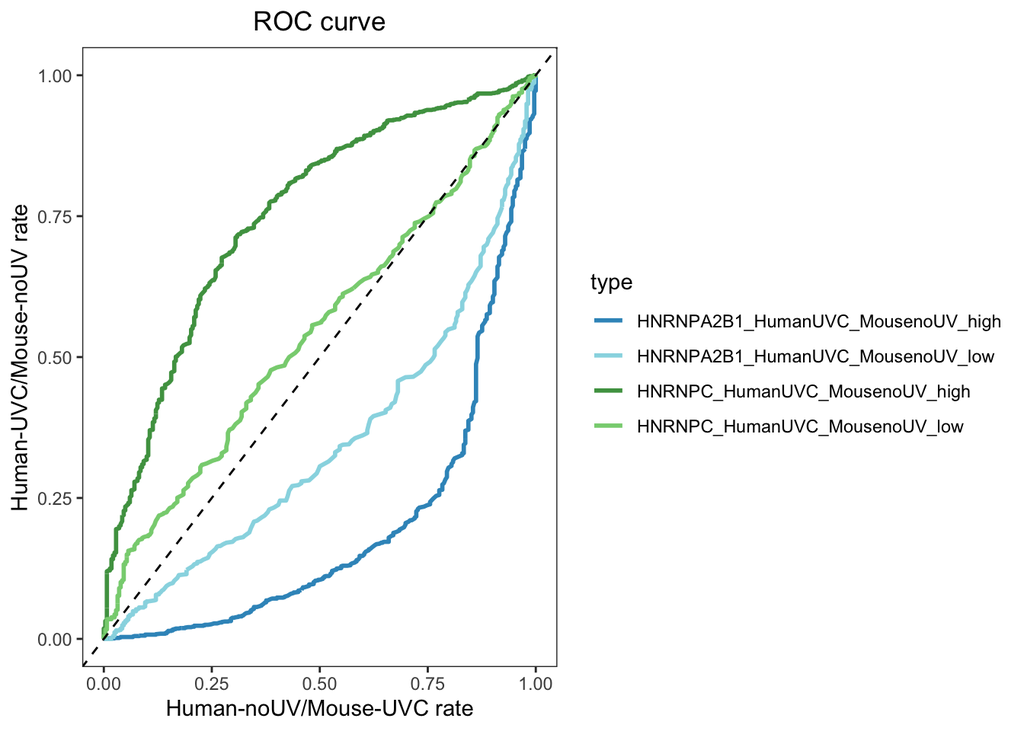

```r
#Prepare data.frame for ROC analysis
unique_pep <- assay(pe[[3]])
unique_pep <- as.data.frame(unique_pep)
rownames(unique_pep) <- pe[[3]]@elementMetadata$name

#Average between samples
unique_pep$HNRNPC_low <- rowMeans(unique_pep[c(1,3)])
unique_pep$HNRNPC_high <- rowMeans(unique_pep[c(2,4)])
unique_pep$HNRNPA2B1_low <- rowMeans(unique_pep[c(5,7)])
unique_pep$HNRNPA2B1_high <- rowMeans(unique_pep[c(6,8)])

#Subset mouse unique peptides
mouse_unique_pep <- unique_pep[grepl("[a-z]", rownames(unique_pep)), ]
mouse_unique_pep$Gene.names <- rownames(mouse_unique_pep)

mouse_HNRNPClow <- mouse_unique_pep[,c(13,9)]
colnames(mouse_HNRNPClow) <- c("Gene.names", "Int")

mouse_HNRNPChigh <- mouse_unique_pep[,c(13,10)]
colnames(mouse_HNRNPChigh) <- c("Gene.names", "Int")

mouse_HNRNPA2B1low <- mouse_unique_pep[,c(13,11)]
colnames(mouse_HNRNPA2B1low) <- c("Gene.names", "Int")

mouse_HNRNPA2B1high <- mouse_unique_pep[,c(13,12)]
colnames(mouse_HNRNPA2B1high) <- c("Gene.names", "Int")

#Subset human unique peptides
'%!in%' <- function(x,y)!('%in%'(x,y))
human_unique_pep <- subset(unique_pep, rownames(unique_pep) %!in% rownames(mouse_unique_pep))
human_unique_pep$Gene.names <- rownames(human_unique_pep)
human_HNRNPClow <- human_unique_pep[,c(13,9)]
colnames(human_HNRNPClow) <- c("Gene.names", "Int")
human_HNRNPChigh <- human_unique_pep[,c(13,10)]
colnames(human_HNRNPChigh) <- c("Gene.names", "Int")
human_HNRNPA2B1low <- human_unique_pep[,c(13,11)]
colnames(human_HNRNPA2B1low) <- c("Gene.names", "Int")
human_HNRNPA2B1high <- human_unique_pep[,c(13,12)]
colnames(human_HNRNPA2B1high) <- c("Gene.names", "Int")

#Perform cumulative fraction analysis
i <- seq(0, 30, by = 0.01)

mouse_ECDF_HNRNPChigh <- data.frame(seq = i, ecdf = 1-(ecdf(mouse_HNRNPChigh$Int)(i)))
colnames(mouse_ECDF_HNRNPChigh) <- c("Seq_m", "ROC_m")
human_ECDF_HNRNPChigh <- data.frame(seq = i, ecdf = 1-(ecdf(human_HNRNPChigh$Int)(i)))
colnames(human_ECDF_HNRNPChigh) <- c("Seq_h", "ROC_h")
HNRNPChigh <- cbind(human_ECDF_HNRNPChigh, mouse_ECDF_HNRNPChigh)
HNRNPChigh$type <- "HNRNPC_HumanUVC_MousenoUV_high"

mouse_ECDF_HNRNPClow <- data.frame(seq = i, ecdf = 1-(ecdf(mouse_HNRNPClow$Int)(i)))
colnames(mouse_ECDF_HNRNPClow) <- c("Seq_m", "ROC_m")
human_ECDF_HNRNPClow <- data.frame(seq = i, ecdf = 1-(ecdf(human_HNRNPClow$Int)(i)))
colnames(human_ECDF_HNRNPClow) <- c("Seq_h", "ROC_h")
HNRNPClow <- cbind(human_ECDF_HNRNPClow, mouse_ECDF_HNRNPClow)
HNRNPClow$type <- "HNRNPC_HumanUVC_MousenoUV_low"

mouse_ECDF_HNRNPA2B1high <- data.frame(seq = i, ecdf = 1-(ecdf(mouse_HNRNPA2B1high$Int)(i)))
colnames(mouse_ECDF_HNRNPA2B1high) <- c("Seq_m", "ROC_m")
human_ECDF_HNRNPA2B1high <- data.frame(seq = i, ecdf = 1-(ecdf(human_HNRNPA2B1high$Int)(i)))
colnames(human_ECDF_HNRNPA2B1high) <- c("Seq_h", "ROC_h")
HNRNPA2B1high <- cbind(human_ECDF_HNRNPA2B1high, mouse_ECDF_HNRNPA2B1high)
HNRNPA2B1high$type <- "HNRNPA2B1_HumanUVC_MousenoUV_high"

mouse_ECDF_HNRNPA2B1low <- data.frame(seq = i, ecdf = 1-(ecdf(mouse_HNRNPA2B1low$Int)(i)))
colnames(mouse_ECDF_HNRNPA2B1low) <- c("Seq_m", "ROC_m")
human_ECDF_HNRNPA2B1low <- data.frame(seq = i, ecdf = 1-(ecdf(human_HNRNPA2B1low$Int)(i)))
colnames(human_ECDF_HNRNPA2B1low) <- c("Seq_h", "ROC_h")
HNRNPA2B1low <- cbind(human_ECDF_HNRNPA2B1low, mouse_ECDF_HNRNPA2B1low)
HNRNPA2B1low$type <- "HNRNPA2B1_HumanUVC_MousenoUV_low"

#Create a dataframe for plotting
roc <- rbind(HNRNPChigh, HNRNPClow, HNRNPA2B1high, HNRNPA2B1low)

ggplot(roc %>% arrange(ROC_h, ROC_m), aes(x = ROC_m, y = ROC_h, color = type)) + geom_line(linewidth = 1) +
  geom_abline(intercept = 0, slope = 1, linetype = "dashed") +
  scale_color_manual(values=c("#3896C4", "#98D9E4","#4E9F50", "#87D180")) +
  theme_bw() +
  theme(panel.grid.major = element_blank(), #legend.position = "none",
        panel.grid.minor = element_blank(),
        panel.background = element_blank(),
        axis.line = element_blank(),
        plot.title = element_text(hjust = 0.5)) +
  ggtitle("ROC curve") +
  ylab("Human-UVC/Mouse-noUV rate") +
  xlab("Human-noUV/Mouse-UVC rate")
```

```r
#Save ROC curve as pdf
pdf("~/Documents/Postdoc/PD_Projects/3_irCLIP-RNP/MS/irCLIP-RNP_control/1_Species_mixing/2_ROC/ROC_MouseHuman.pdf", width = 5, height = 5)
ggplot(roc %>% arrange(ROC_h, ROC_m), aes(x = ROC_m, y = ROC_h, color = type)) + geom_line(linewidth = 1) +
  geom_abline(intercept = 0, slope = 1, linetype = "dashed") +
  scale_color_manual(values=c("#3896C4", "#98D9E4","#4E9F50", "#87D180")) +
  theme_bw() +
  theme(panel.grid.major = element_blank(), legend.position = "none",
        panel.grid.minor = element_blank(),
        panel.background = element_blank(),
        axis.line = element_blank(),
        plot.title = element_text(hjust = 0.5)) +
  ggtitle("ROC curve") +
  ylab("Human-UVC/Mouse-noUV rate") +
  xlab("Human-noUV/Mouse-UVC rate")
dev.off()
```

# 4. Distribution of mouse/Human unique peptide accross RBPs

At this point, we displayed the ratio of imputed intensity of mouse/human unique peptides across some RBPs in the Human-UVC/Mouse-noUV and Human-noUV/Mouse-UVC samples. We used only the intensities coming from the gel section referred here as “high” (a.k.a. whole RNP zone) ranging from 70-350kDa.

```r
#Function to draw the lolliplot
get_lolliplot <- function(gene, species, taxid, orgDB){
APIurl <- "https://www.ebi.ac.uk/proteins/api/"
eid <- mget(gene, get(sub(".db", "SYMBOL2EG", orgDB)))[[1]]
chr <- mget(eid, get(sub(".db", "CHR", orgDB)))[[1]]
accession <- unlist(lapply(eid, function(.ele){mget(.ele, get(sub(".db", "UNIPROT", orgDB)))}))
featureURL <- paste0(APIurl, "features?offset=0&size=-1&reviewed=true","&types=DNA_BIND%2CMOTIF%2CDOMAIN", "&taxid=", taxid,
                     "&accession=", paste(accession, collapse = "%2C"))
response <- GET(featureURL)
content <- httr::content(response)
content <- content[[1]]
acc <- content$accession
sequence <- content$sequence
gr <- GRanges(chr, IRanges(1, nchar(sequence)))
domains <- do.call(rbind, content$features)
domains <- GRanges(chr, IRanges(as.numeric(domains[, "begin"]),as.numeric(domains[, "end"]),names = domains[, "description"]))
domains$fill <- 1+seq_along(domains)
domains$height <- 0.04
fasta = readLines(paste("~/Documents/Postdoc/PD_Projects/3_irCLIP-RNP/MS/irCLIP-RNP_control/1_Species_mixing/3_Intensity_plot/", gene, "_", species, "_sequence.fasta", sep = ""))
ids = grepl(">", fasta)
rbp.f = data.frame(id = sub(">", "", fasta[ids]), s = tapply(fasta[!ids], cumsum(ids)[!ids], function(x) {paste(x, collapse = "")}))
rbp <- unique_pep[rownames(unique_pep) %like% gene, ]
rbp$name <- rownames(rbp)
rbp <- merge(rbp, data[c(37,84)], by = "name")
SNP <- sort(rbp$Start.position)

sample.gr <- GRanges(as.character(seqnames(domains)@values), IRanges(SNP, width=1, names=paste0(SNP)))
total_rbp_int <- (2^((rbp$HNRNPC_high_1+rbp$HNRNPC_high_2)/2)+2^((rbp$HNRNPA2B1_high_1+rbp$HNRNPA2B1_high_2)/2))

sample.gr$value1 <- 2^((rbp$HNRNPC_high_1+rbp$HNRNPC_high_2)/2)/total_rbp_int
sample.gr$value2 <- 2^((rbp$HNRNPA2B1_high_1+rbp$HNRNPA2B1_high_2)/2)/total_rbp_int
sample.gr$color <- rep(list(c("#87CEFA", '#98CE31')), length(SNP))
sample.gr$border <- "gray30"

features <- GRanges(as.character(seqnames(domains)@values), IRanges(c(1), width=nchar(rbp.f$s), names=paste0("block", 1)))
features$height <- c(0.03)

legend <- list(labels=c("Human-UVC/Mouse-noUV", "Human-noUV/Mouse-UVC"), fill=c("#87CEFA", '#98CE31'))

features.mul <- c(features, domains)
features.mul$height[c(2:(length(domains)+1))] <- c(rep(0.01, length(domains)))
features.mul$fill <- c("#FF8833", c(paletteer_c("grDevices::YlGnBu", (length(features.mul)-1))))
features.mul$featureLayerID <- c("tx_1", paste("tx", rep(2, each=length(domains)), sep="_"))
names(features.mul) <- c(gene, names(domains))
lolliplot <- lolliplot(sample.gr, features.mul, legend = legend, ylab="Percentage imputed intensity", type="pie")
return(lolliplot)
}
```

## Human RBPs

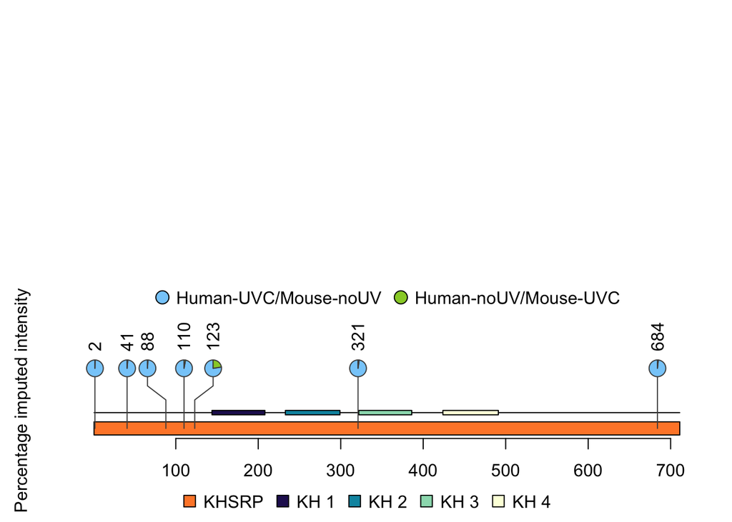

```r
#Get lolliplot for human RBPs
KHSRP.h.lolliplot <- get_lolliplot("KHSRP", "Human", "9606","org.Hs.eg.db")
```

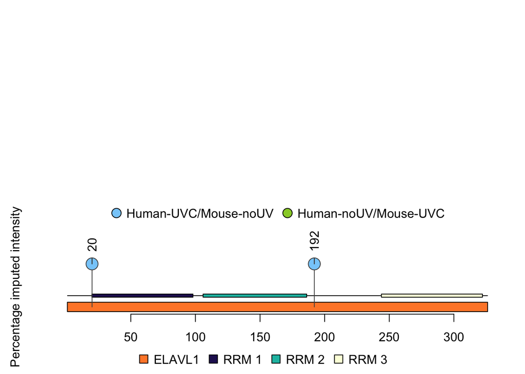

```r
ELAVL1.h.lolliplot <- get_lolliplot("ELAVL1", "Human", "9606","org.Hs.eg.db")
```

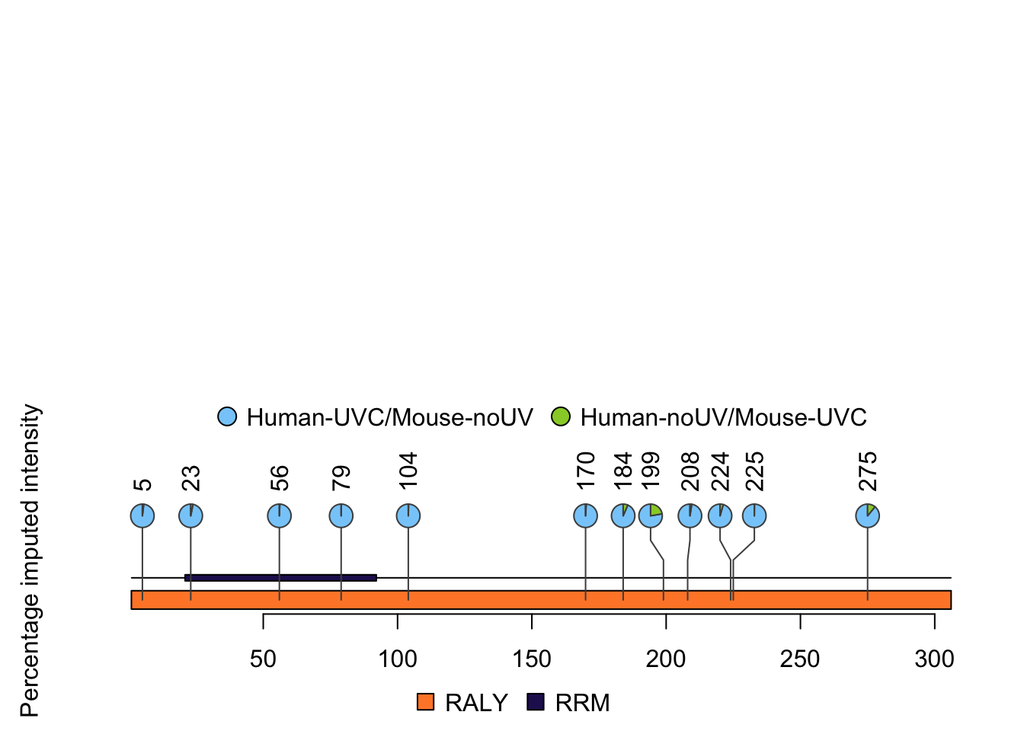

```r
RALY.h.lolliplot <- get_lolliplot("RALY", "Human", "9606","org.Hs.eg.db")
```

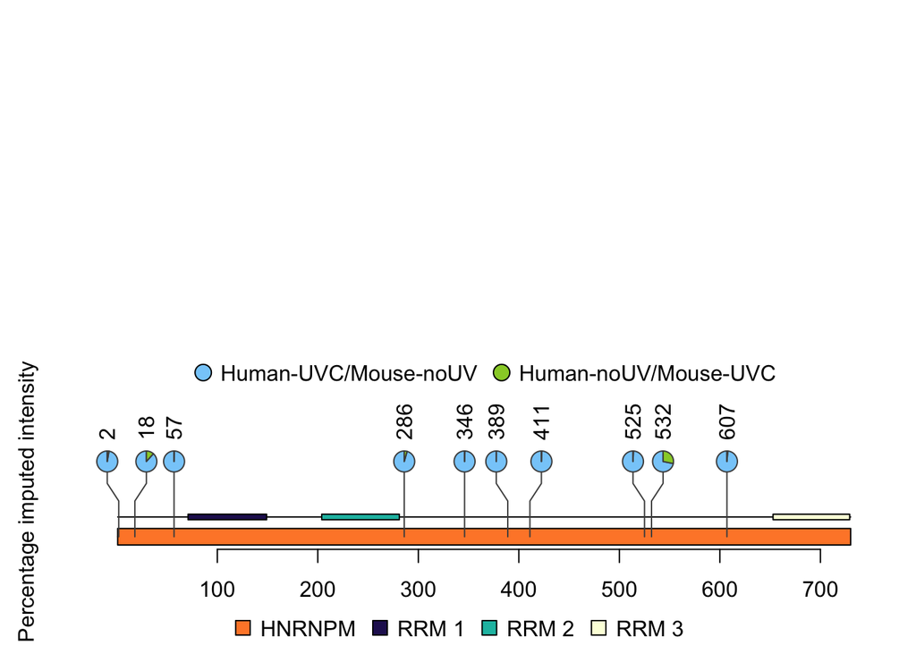

```r
HNRNPM.h.lolliplot <- get_lolliplot("HNRNPM", "Human", "9606","org.Hs.eg.db")
```

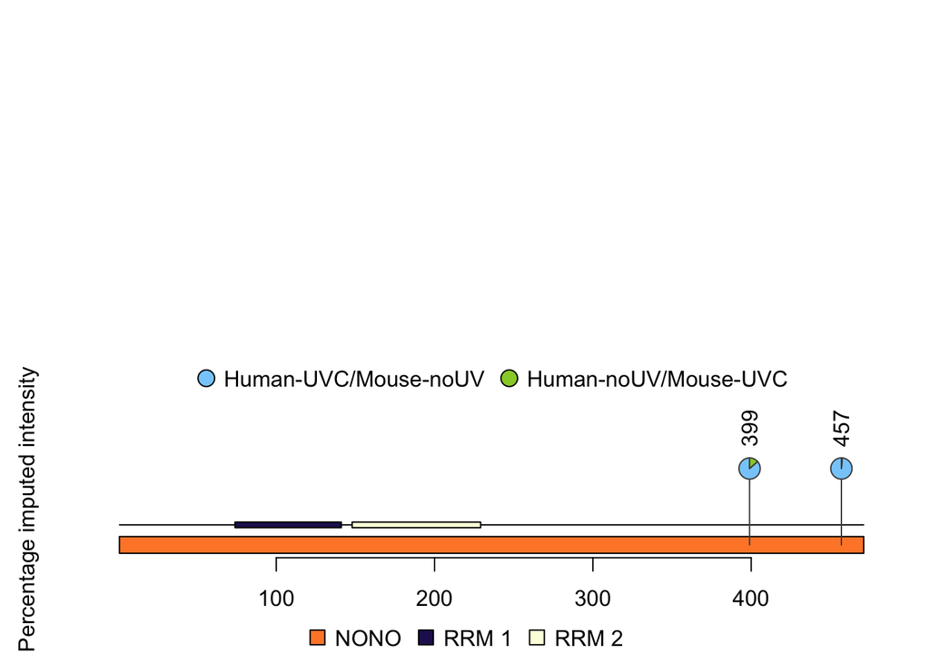

```r
NONO.h.lolliplot <- get_lolliplot("NONO", "Human", "9606","org.Hs.eg.db")
```

```r
#Save human lolliplot as pdf
pdf("~/Documents/Postdoc/PD_Projects/3_irCLIP-RNP/MS/irCLIP-RNP_control/1_Species_mixing/3_Intensity_plot/Human_Lolliplot.pdf")
KHSRP.h.lolliplot <- get_lolliplot("KHSRP", "Human", "9606","org.Hs.eg.db")
ELAVL1.h.lolliplot <- get_lolliplot("ELAVL1", "Human", "9606","org.Hs.eg.db")
RALY.h.lolliplot <- get_lolliplot("RALY", "Human", "9606","org.Hs.eg.db")
HNRNPM.h.lolliplot <- get_lolliplot("HNRNPM", "Human", "9606","org.Hs.eg.db")
NONO.h.lolliplot <- get_lolliplot("NONO", "Human", "9606","org.Hs.eg.db")
dev.off()
```

## Mouse RBPs

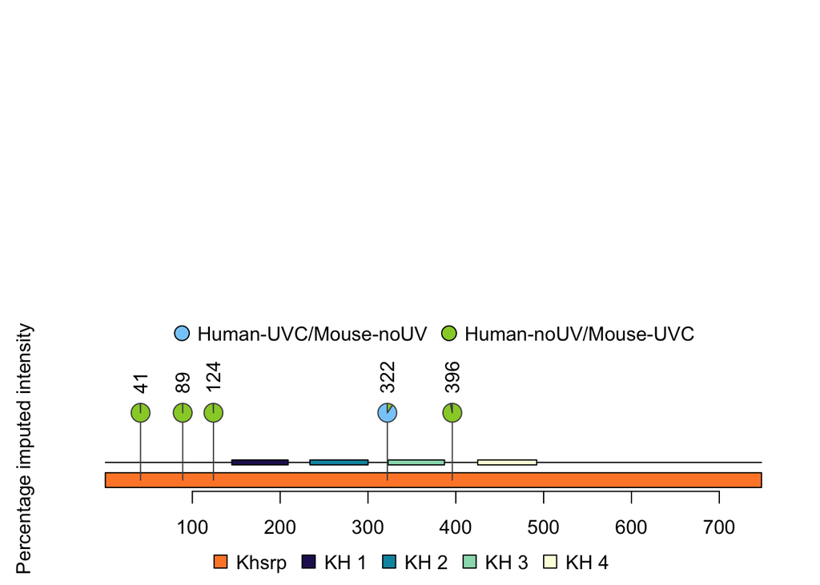

```r
#Get lolliplot for mouse RBPs
Khsrp.m.lolliplot <- get_lolliplot("Khsrp", "Mouse", "10090", "org.Mm.eg.db")
```

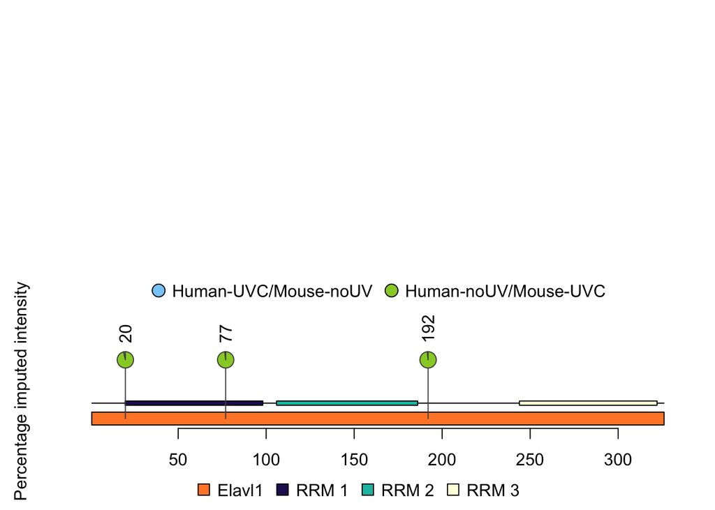

```r
Elavl1.m.lolliplot <- get_lolliplot("Elavl1", "Mouse", "10090", "org.Mm.eg.db")
```

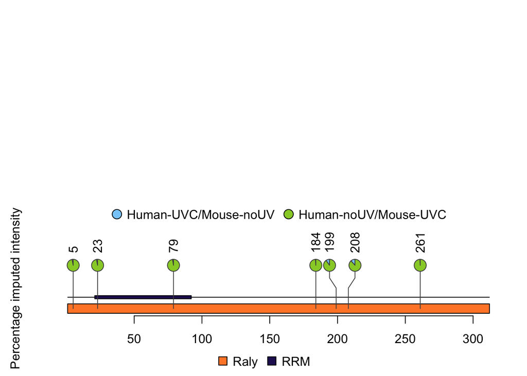

```r
Raly.m.lolliplot <- get_lolliplot("Raly", "Mouse", "10090", "org.Mm.eg.db")
```

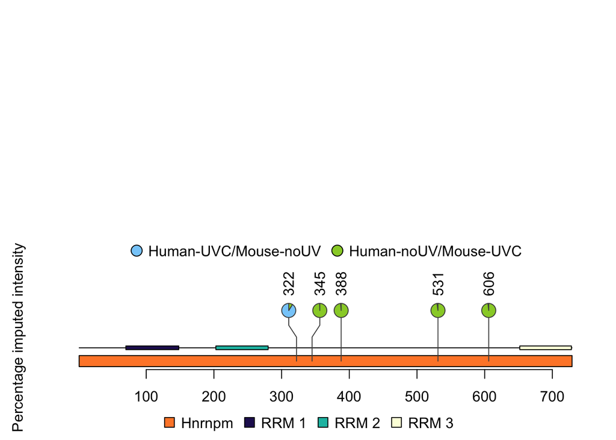

```r
Hnrnpm.m.lolliplot <- get_lolliplot("Hnrnpm", "Mouse", "10090", "org.Mm.eg.db")
```

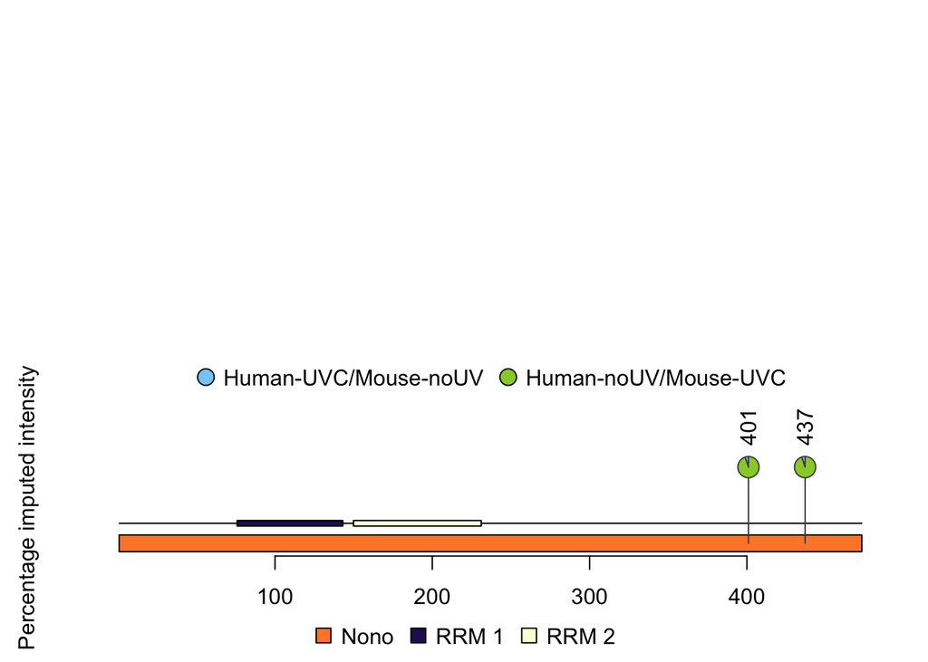

```r
Nono.m.lolliplot <- get_lolliplot("Nono", "Mouse", "10090", "org.Mm.eg.db")
```

```r
#Save mouse lolliplot as pdf
pdf("~/Documents/Postdoc/PD_Projects/3_irCLIP-RNP/MS/irCLIP-RNP_control/1_Species_mixing/3_Intensity_plot/Mouse_Lolliplot.pdf")
Khsrp.m.lolliplot <- get_lolliplot("Khsrp", "Mouse", "10090", "org.Mm.eg.db")
Elavl1.m.lolliplot <- get_lolliplot("Elavl1", "Mouse", "10090", "org.Mm.eg.db")
Raly.m.lolliplot <- get_lolliplot("Raly", "Mouse", "10090", "org.Mm.eg.db")
Hnrnpm.m.lolliplot <- get_lolliplot("Hnrnpm", "Mouse", "10090", "org.Mm.eg.db")
Nono.m.lolliplot <- get_lolliplot("Nono", "Mouse", "10090", "org.Mm.eg.db")
dev.off()
```

All the visualizations were saved as pdf and modified in illustrator.